# Project 1 - Reproducible Research

Keana Bautista

2023-07-05

=========================

## Loading and pre-processing the data

We will first read the csv file and omit the NA values

```r
activity <- read.csv("activity.csv")
c_data <- na.omit(activity)
c_data$date <- as.Date(c_data$date)
```

To calculate the mean total number of steps taken per day, group first the data by date and take the sum of steps taken per day.

```r
library(dplyr)
grouped_sum <- c_data %>% group_by(date) %>% summarise(sum_steps = sum(steps))
df <- grouped_sum %>% as.data.frame()
```

Here’s a histogram of the number of steps taken each day.

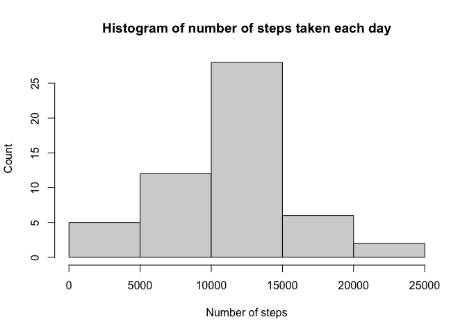

```r
hist(df$sum_steps, main='Histogram of number of steps taken each day', xlab='Number of steps', ylab =' Count')
```

```r
df_mean <- mean(df$sum_steps)
df_median <- median(df$sum_steps)
```

## What is the average daily activity pattern?

To get a time series plot of the average number of steps taken, group the data by interval and get the mean of the steps.

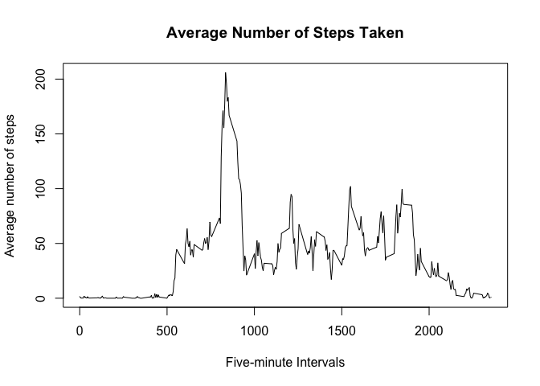

```r
library(dplyr)
grouped_mean <- c_data %>% group_by(interval) %>% summarise(mean_steps = mean(steps))
plot(grouped_mean, type="l", xlab='Five-minute Intervals', ylab='Average number of steps', main='Average Number of Steps Taken')
```

To get the 5-minute interval that, on average, contains the maximum number of steps, use the function which.max()

```r
max_step_interval <- grouped_mean$interval[which.max(grouped_mean$mean_steps)]
```

The 5-minute interval the has the highest average number of steps was during 835

## Inputing missing values

```r
missing_data <- sum(is.na(activity$steps))
```

To fill in the missing (NA) data, we will get the mean of the number of steps of that particular interval over all days and assign them to the corresponsing NAs.

```r
mean_missing_data<- activity

for(i in 1:nrow(mean_missing_data)){
    if(is.na(mean_missing_data$steps[i])){
      x <- which(mean_missing_data$interval[i] == grouped_mean$interval)
      mean_missing_data$steps[i] <- grouped_mean[x,]$mean_steps
    }
}

mean_missing_data$date <-as.Date(mean_missing_data$date)
```

Group the filled data set by date and get the sum of steps

```r
library(dplyr)
mean_missing_steps <- mean_missing_data %>%
    group_by(date) %>%
    summarise(sum_steps=sum(steps))
```

Here’s a histogram of the filled data set

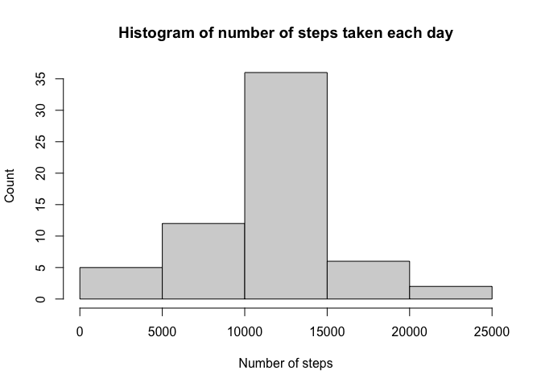

```r
hist(mean_missing_steps$sum_steps, main='Histogram of number of steps taken each day', xlab='Number of steps', ylab = 'Count')
```

The mean and median of the total number of steps taken each day are as follows:

```r
filldata_mean <- mean(mean_missing_steps$sum_steps)
filldata_median <- median(mean_missing_steps$sum_steps)
```

The computed mean is 10766.1886792453 while the median is 10766.1886792453. Mean remains unchanged by the median has increased slightly since we input missing data based on average.

## Are there differences in activity patterns between weekdays and weekends?

First, create a weekday variable and define the days using weekdays() function.

```r
mean_missing_data$day <- weekdays(mean_missing_data$date)
mean_missing_data$daytype <- "weekday"
mean_missing_data$daytype[mean_missing_data$day %in% c('Saturday', 'Sunday')] <- "weekend"
```

To calculate the mean weekday steps and the mean weekend steps, group the data by 5 minute interval

```r
library(dplyr)
daytype_mean <- mean_missing_data %>%
    group_by(daytype,interval) %>%
    summarise(mean_steps=mean(steps))
```

Here’s a time series plot of weekday vs weekends using ggplot2

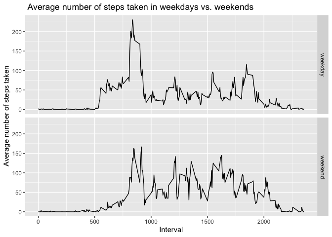

```r
library(ggplot2)
qplot(interval, mean_steps, data=daytype_mean, type='l', main=' Average number of steps taken in weekdays vs. weekends', geom='line',
      xlab="Interval", ylab="Average number of steps taken", facets=daytype ~.)
```